# BCB420 Assignemnt 1

George Ly

I have chosen to work on a data-set exploring the differences in gene expression of patients with asthma in response to the SARS-CoV-2 virus.

I have chosen this data-set to work with as asthma is a problem myself and others in my family have struggled with in the past. With asthma being a respiratory disease, I am curious to know what possible effects it could have in conjunction with another respiratory illness such as COVID-19.

```r
if (!file.exists("GSE158752_IMSA_BEC-RAW_Counts.txt")) {
  GEOquery::getGEOSuppFiles("GSE158752",makeDirectory = FALSE)
  gunzip("GSE158752_IMSA_BEC-RAW_Counts.txt.gz")
}
```

```r
rawCounts = read.table("GSE158752_IMSA_BEC-RAW_Counts.txt",header=TRUE,
                       row.names = 1, check.names = FALSE)
nrow(rawCounts)
```

```
## [1] 26364
```

```r
rownames(rawCounts)[1:10]
```

```
##  [1] "A1BG"     "A1BG-AS1" "A1CF"     "A2M"      "A2M-AS1"  "A2ML1"
##  [7] "A2MP1"    "A3GALT2"  "A4GALT"   "A4GNT"
```

```r
summarizedGeneCounts <- sort(table(rownames(rawCounts)),decreasing = TRUE)
summarizedGeneCounts[1:10]
```

```
##
##     A1BG A1BG-AS1     A1CF      A2M  A2M-AS1    A2ML1    A2MP1  A3GALT2
##        1        1        1        1        1        1        1        1
##   A4GALT    A4GNT
##        1        1
```

```r
ncol(rawCounts)
```

```
## [1] 67
```

```r
colnames(rawCounts)[1:10]
```

```
##  [1] "IMSA001_EPI_H" "IMSA002_EPI_H" "IMSA004_EPI_S" "IMSA005_EPI_M"
##  [5] "IMSA006_EPI_M" "IMSA007_EPI_S" "IMSA008_EPI_M" "IMSA010_EPI_M"
##  [9] "IMSA011_EPI_M" "IMSA012_EPI_H"
```

There are 67 samples within this experiment.

The samples are split into three groups, the control group “Healthy” with no asthma, and two experimental groups with “Mild” Asthma and “Severe” Asthma. These are represented respectively by “H”, “M”, & “S”.

```r
sum(unlist(lapply(colnames(rawCounts),grep,pattern="_H")))
```

```
## [1] 17
```

```r
sum(unlist(lapply(colnames(rawCounts),grep,pattern="_M")))
```

```
## [1] 25
```

```r
sum(unlist(lapply(colnames(rawCounts),grep,pattern="_S")))
```

```
## [1] 25
```

```r
samples <- data.frame(lapply(colnames(rawCounts),
                      FUN=function(x){unlist(strsplit(x, split = "\\_"))[c(1,3)]}))
colnames(samples) <- colnames(rawCounts)
rownames(samples) <- c("Patient","Asthma_severity")
samples <- data.frame(t(samples))
```

There are 17 healthy samples, and 25 samples with mild and severe asthma.

```r
cpms = edgeR::cpm(rawCounts)
keep = rowSums(cpms >1) >=67
countsFiltered = rawCounts[keep,]
nrow(countsFiltered)
```

```
## [1] 12865
```

```r
filteredDataMatrix <- as.matrix(countsFiltered)
d = edgeR::DGEList(counts=filteredDataMatrix, group=samples$Asthma_severity)
d = edgeR::calcNormFactors(d)
TMMCounts = edgeR::cpm(d)
```

I chose to use the TMM normalization method in favour of distribution based methods as there are less control samples when compared to the two experimental sample sets.

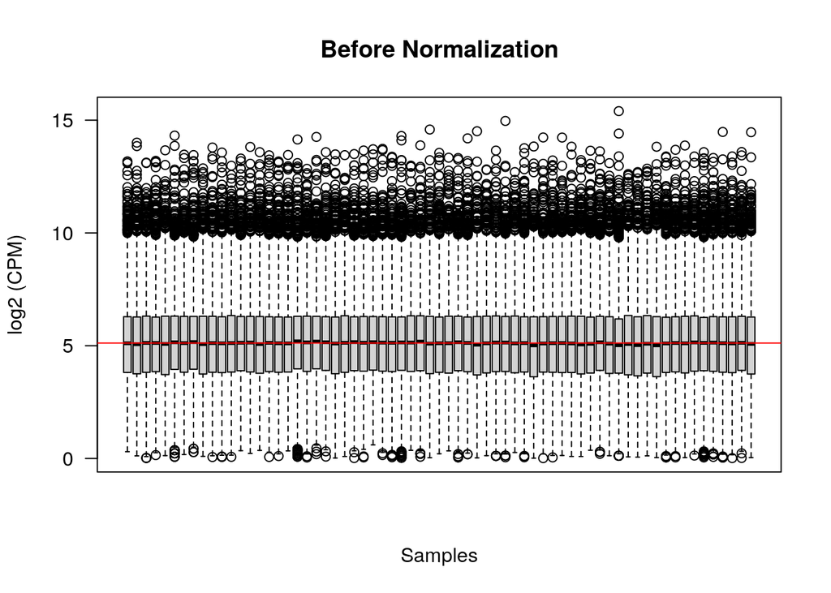

```r
originalData <- log2(edgeR::cpm(countsFiltered))
boxplot(originalData, xlab = "Samples", ylab = "log2 (CPM)", las=2, xaxt='n', main = "Before Normalization")
abline(h = median(apply(originalData, 2, median)), col = "red")
```

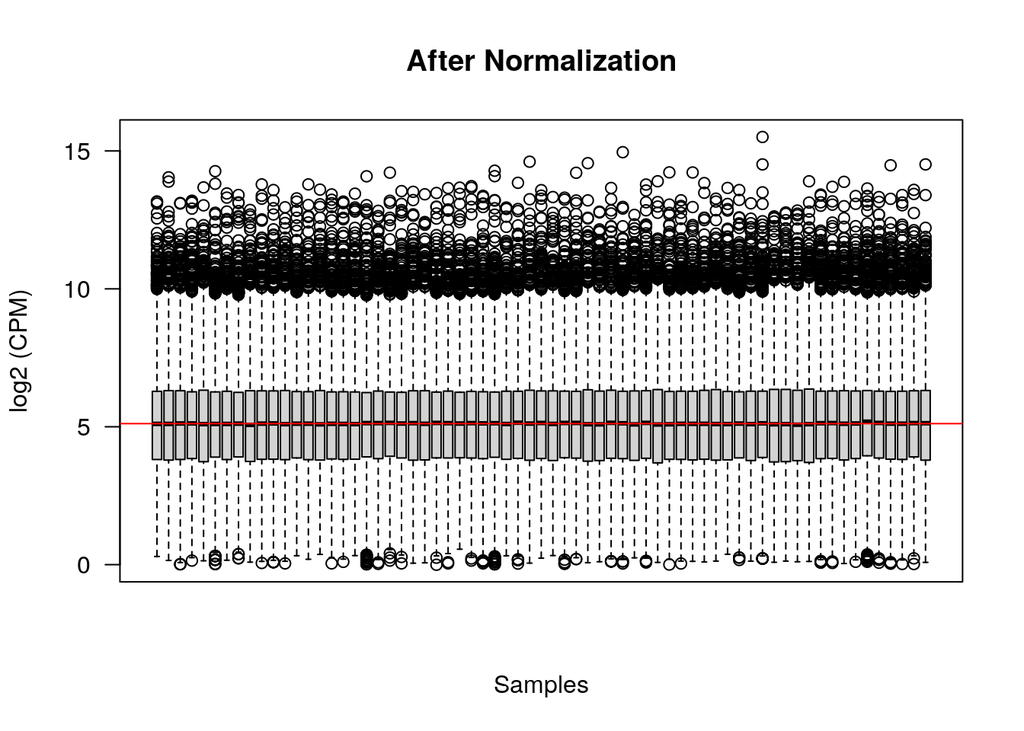

```r
normData <- log2(TMMCounts)
boxplot(normData, xlab = "Samples", ylab = "log2 (CPM)", las=2, xaxt='n', main = "After Normalization")
abline(h = median(apply(normData, 2, median)), col = "red")
```

As expected the normalization does not change the results of the box-plot very much.

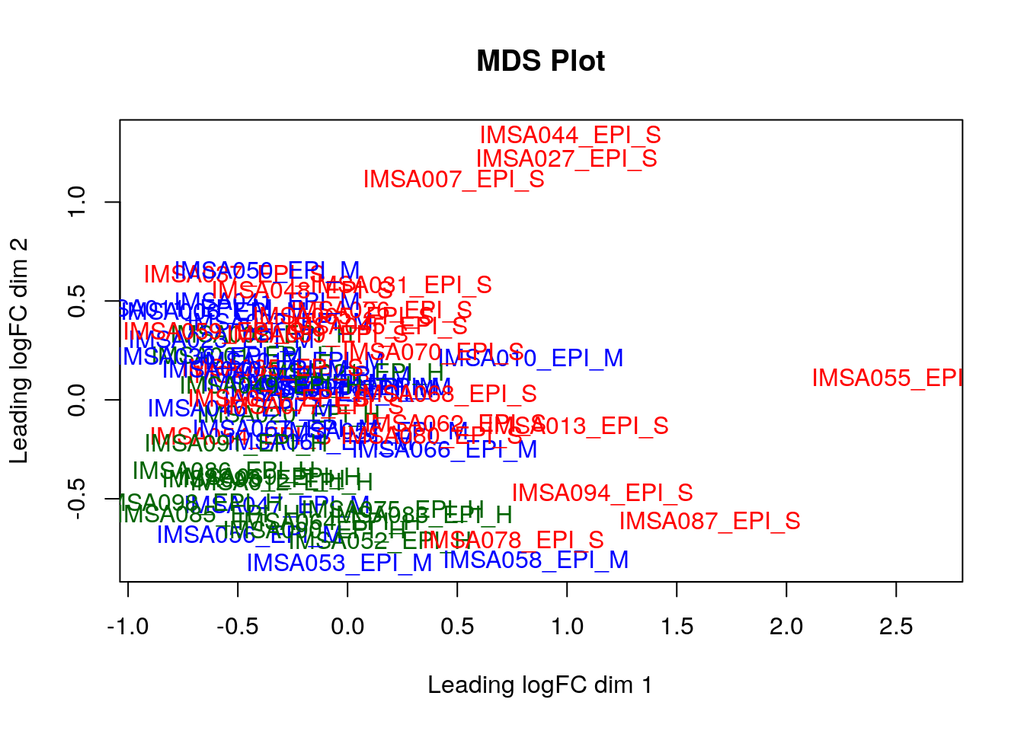

```r
limma::plotMDS(d, labels=rownames(samples),
        col = c("darkgreen","blue","red")[factor(samples$Asthma_severity)], main = "MDS Plot")
```

The MDS shows samples with healthy and moderate cases of Asthma being clustered close together. Severe cases of asthma are more likely to be farther away from the main cluster.